# DALEX docs archived objects

Alicja Gosiewska

17 May 2018

```r
library(archivist)
library(DALEX)
library(gbm)
library(ggplot2)
library(knitr)
library(randomForest)
```

# Chapter 2 Architecture of DALEX

## 2.2 Use case: Regression. Apartment prices in Warsaw

```r
library(DALEX)
head(apartments)
```

| m2.price | construction.year | surface | floor | no.rooms | district |
| --- | --- | --- | --- | --- | --- |
| 5897 | 1953 | 25 | 3 | 1 | Srodmiescie |
| 1818 | 1992 | 143 | 9 | 5 | Bielany |
| 3643 | 1937 | 56 | 1 | 2 | Praga |
| 3517 | 1995 | 93 | 7 | 3 | Ochota |
| 3013 | 1992 | 144 | 6 | 5 | Mokotow |
| 5795 | 1926 | 61 | 6 | 2 | Srodmiescie |

### 2.2.1 Model 1: Linear regression

```r
apartments_lm_model <- lm(m2.price ~ construction.year + surface + floor +
                         no.rooms + district, data = apartments)
summary(apartments_lm_model)
```

```
Call:
lm(formula = m2.price ~ construction.year + surface + floor +
    no.rooms + district, data = apartments)

Residuals:
   Min     1Q Median     3Q    Max
-247.5 -202.8 -172.8  381.4  469.0

Coefficients:
                     Estimate Std. Error t value Pr(>|t|)
(Intercept)         5020.1391   682.8721   7.352 4.11e-13 ***
construction.year     -0.2290     0.3483  -0.657   0.5110
surface              -10.2378     0.5778 -17.720  < 2e-16 ***
floor                -99.4820     3.0874 -32.222  < 2e-16 ***
no.rooms             -37.7299    15.8440  -2.381   0.0174 *
districtBielany       17.2144    40.4502   0.426   0.6705
districtMokotow      918.3802    39.4386  23.286  < 2e-16 ***
districtOchota       926.2540    40.5279  22.855  < 2e-16 ***
districtPraga        -37.1047    40.8930  -0.907   0.3644
districtSrodmiescie 2080.6110    40.0149  51.996  < 2e-16 ***
districtUrsus         29.9419    39.7249   0.754   0.4512
districtUrsynow      -18.8651    39.7565  -0.475   0.6352
districtWola         -16.8912    39.6283  -0.426   0.6700
districtZoliborz     889.9735    40.4099  22.024  < 2e-16 ***
---
Signif. codes:  0 '***' 0.001 '**' 0.01 '*' 0.05 '.' 0.1 ' ' 1

Residual standard error: 281.3 on 986 degrees of freedom
Multiple R-squared:  0.905, Adjusted R-squared:  0.9037
F-statistic: 722.5 on 13 and 986 DF,  p-value: < 2.2e-16
```

Load apartments_lm_model: [`archivist::aread('pbiecek/DALEX_arepo/3cafc60134a96b55cfc6071331e0b4e8')`](https://raw.githubusercontent.com/pbiecek/DALEX_arepo/master/gallery/3cafc60134a96b55cfc6071331e0b4e8.rda)

```r
predicted_mi2_lm <- predict(apartments_lm_model, apartmentsTest)
sqrt(mean((predicted_mi2_lm - apartmentsTest$m2.price)^2))
```

[1] 283.0865

```r
explainer_lm <- explain(apartments_lm_model,
                          data = apartmentsTest[,2:6], y = apartmentsTest$m2.price)
```

Load explainer_lm: [`archivist::aread('pbiecek/DALEX_arepo/9cca29103ef24810307f2bd4c7919198')`](https://raw.githubusercontent.com/pbiecek/DALEX_arepo/master/gallery/9cca29103ef24810307f2bd4c7919198.rda)

### 2.2.2 Model 2: Random forest

```r
library("randomForest")
set.seed(59)

apartments_rf_model <- randomForest(m2.price ~ construction.year + surface + floor +
                      no.rooms + district, data = apartments)
apartments_rf_model
```

```
Call:
 randomForest(formula = m2.price ~ construction.year + surface +      floor + no.rooms + district, data = apartments)
               Type of random forest: regression
                     Number of trees: 500
No. of variables tried at each split: 1

          Mean of squared residuals: 82614.7
                    % Var explained: 89.94
```

Load apartments_rf_model: [`archivist::aread('pbiecek/DALEX_arepo/dd78d435bf6e7c94d2286b5ca6be4909')`](https://raw.githubusercontent.com/pbiecek/DALEX_arepo/master/gallery/dd78d435bf6e7c94d2286b5ca6be4909.rda)

```r
predicted_mi2_rf <- predict(apartments_rf_model, apartmentsTest)
sqrt(mean((predicted_mi2_rf - apartmentsTest$m2.price)^2))
```

[1] 286.5357

```r
explainer_rf <- explain(apartments_rf_model,
                       data = apartmentsTest[,2:6], y = apartmentsTest$m2.price)
```

Load explainer_rf: [`archivist::aread('pbiecek/DALEX_arepo/c8989ccd4160e539739b2f1204556451')`](https://raw.githubusercontent.com/pbiecek/DALEX_arepo/master/gallery/c8989ccd4160e539739b2f1204556451.rda)

# Chapter 3 Model understanding

```r
library("DALEX")
apartments_lm_model <- lm(m2.price ~ construction.year + surface + floor +
                      no.rooms + district, data = apartments)

library("randomForest")
set.seed(59)
apartments_rf_model <- randomForest(m2.price ~ construction.year + surface + floor +
                      no.rooms + district, data = apartments)
```

Load apartments_lm_model: [`archivist::aread('pbiecek/DALEX_arepo/3cafc60134a96b55cfc6071331e0b4e8')`](https://raw.githubusercontent.com/pbiecek/DALEX_arepo/master/gallery/3cafc60134a96b55cfc6071331e0b4e8.rda)

Load apartments_rf_model: [`archivist::aread('pbiecek/DALEX_arepo/dd78d435bf6e7c94d2286b5ca6be4909')`](https://raw.githubusercontent.com/pbiecek/DALEX_arepo/master/gallery/dd78d435bf6e7c94d2286b5ca6be4909.rda)

```r
explainer_lm <- explain(apartments_lm_model,
                       data = apartmentsTest[,2:6], y = apartmentsTest$m2.price)

explainer_rf <- explain(apartments_rf_model,
                       data = apartmentsTest[,2:6], y = apartmentsTest$m2.price)
```

Load explainer_lm: [`archivist::aread('pbiecek/DALEX_arepo/9cca29103ef24810307f2bd4c7919198')`](https://raw.githubusercontent.com/pbiecek/DALEX_arepo/master/gallery/9cca29103ef24810307f2bd4c7919198.rda)

Load explainer_rf: [`archivist::aread('pbiecek/DALEX_arepo/c8989ccd4160e539739b2f1204556451')`](https://raw.githubusercontent.com/pbiecek/DALEX_arepo/master/gallery/c8989ccd4160e539739b2f1204556451.rda)

## 3.1 Model performance

```r
predicted_mi2_lm <- predict(apartments_lm_model, apartmentsTest)
sqrt(mean((predicted_mi2_lm - apartmentsTest$m2.price)^2))
```

[1] 283.0865

```r
predicted_mi2_rf <- predict(apartments_rf_model, apartmentsTest)
sqrt(mean((predicted_mi2_rf - apartmentsTest$m2.price)^2))
```

[1] 286.5357

```r
mp_lm <- model_performance(explainer_lm)
mp_rf <- model_performance(explainer_rf)
mp_lm
```

```
       0%       10%       20%       30%       40%       50%       60%
-472.3560 -423.9131 -398.2811 -370.8841  161.2473  174.0677  184.1412
      70%       80%       90%      100%
 195.8834  209.2460  221.4659  257.2555
```

```r
mp_rf
```

```
          0%          10%          20%          30%          40%
-1262.554308  -408.920183  -197.591180   -89.661883    -7.454146
         50%          60%          70%          80%          90%
   55.441061   108.398858   157.924244   218.241574   294.264602
        100%
  727.445065
```

Load mp_lm: [`archivist::aread('pbiecek/DALEX_arepo/3927999b40b4818645bb2d4d152a3982')`](https://raw.githubusercontent.com/pbiecek/DALEX_arepo/master/gallery/3927999b40b4818645bb2d4d152a3982.rda)

Load mp_rf: [`archivist::aread('pbiecek/DALEX_arepo/b4eb12644fbb0caad889c7f830a8a364')`](https://raw.githubusercontent.com/pbiecek/DALEX_arepo/master/gallery/b4eb12644fbb0caad889c7f830a8a364.rda)

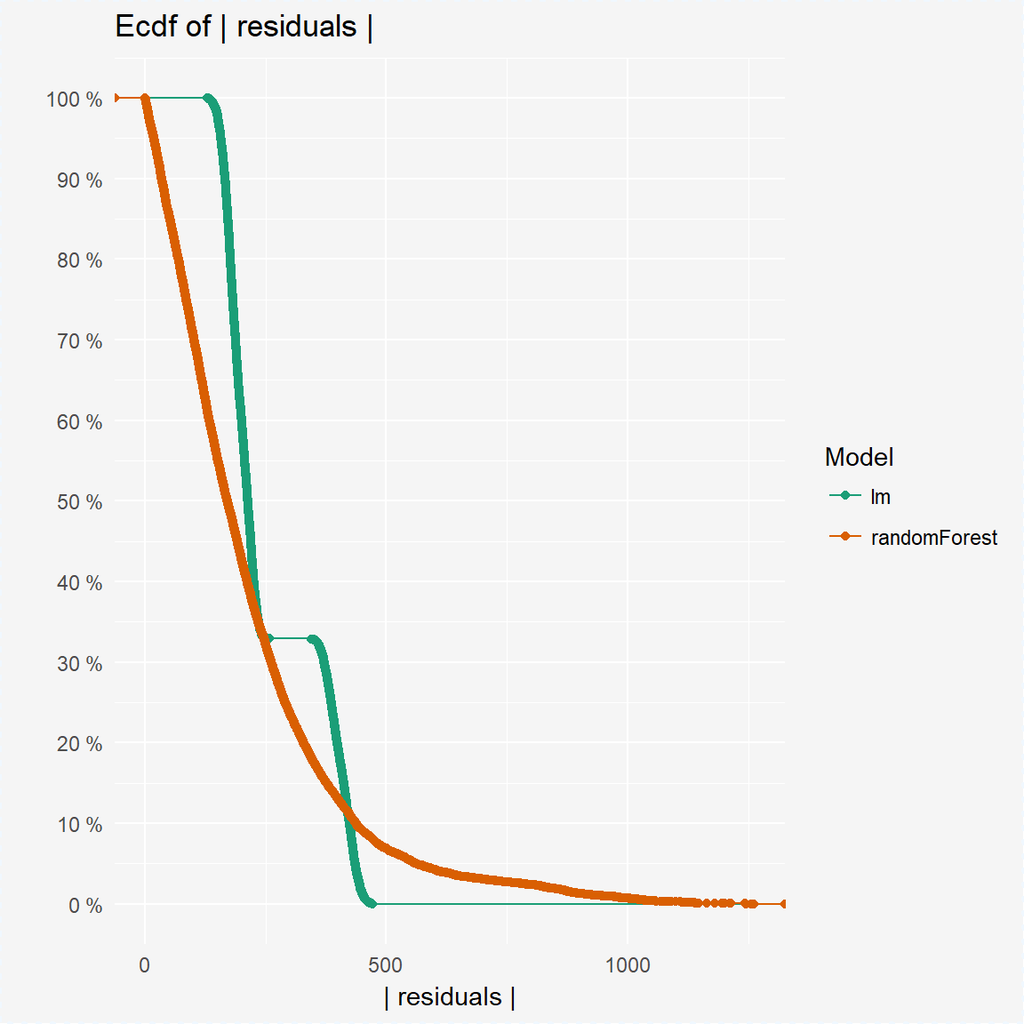

```r
plot(mp_lm, mp_rf)
```

Load plot: [`archivist::aread('pbiecek/DALEX_arepo/5fc1ad4645a8494120e6a0fe56b1bd3a')`](https://raw.githubusercontent.com/pbiecek/DALEX_arepo/master/gallery/5fc1ad4645a8494120e6a0fe56b1bd3a.rda)

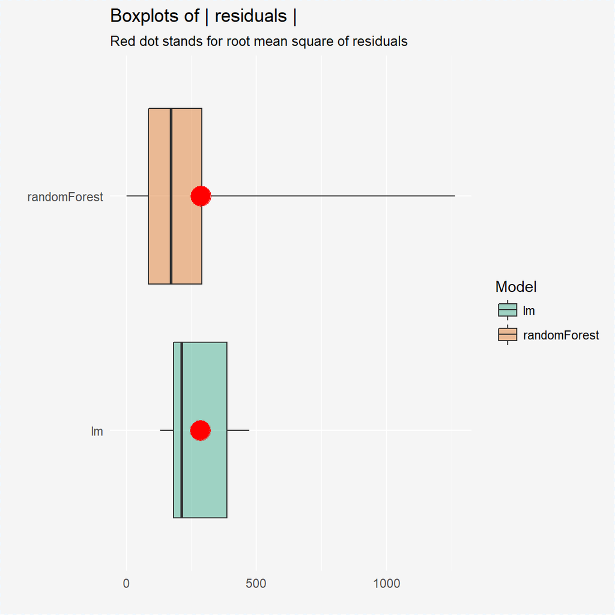

```r
plot(mp_lm, mp_rf, geom = "boxplot")
```

Load plot: [`archivist::aread('pbiecek/DALEX_arepo/bde139f879f1191ae28c12220eb98718')`](https://raw.githubusercontent.com/pbiecek/DALEX_arepo/master/gallery/bde139f879f1191ae28c12220eb98718.rda)

## 3.2 Feature importance

### 3.2.1 Model agnostic

```r
vi_rf <- variable_importance(explainer_rf, loss_function = loss_root_mean_square)
vi_rf
```

```
           variable dropout_loss        label
1      _full_model_     285.1355 randomForest
2          no.rooms     391.0710 randomForest
3 construction.year     410.5866 randomForest
4             floor     445.2164 randomForest
5           surface     480.1431 randomForest
6          district     843.6519 randomForest
7        _baseline_    1081.3710 randomForest
```

Load vi_rf: [`archivist::aread('pbiecek/DALEX_arepo/026249b1023995c18d9669ba047a25b6')`](https://raw.githubusercontent.com/pbiecek/DALEX_arepo/master/gallery/026249b1023995c18d9669ba047a25b6.rda)

```r
vi_lm <- variable_importance(explainer_lm, loss_function = loss_root_mean_square)
vi_lm
```

```
           variable dropout_loss label
1      _full_model_     284.2788    lm
2 construction.year     284.2638    lm
3          no.rooms     295.5020    lm
4             floor     495.7685    lm
5           surface     600.4308    lm
6          district    1025.7208    lm
7        _baseline_    1232.6798    lm
```

Load vi_lm: [`archivist::aread('pbiecek/DALEX_arepo/924cf8dfca2dd5975397448975a495d0')`](https://raw.githubusercontent.com/pbiecek/DALEX_arepo/master/gallery/924cf8dfca2dd5975397448975a495d0.rda)

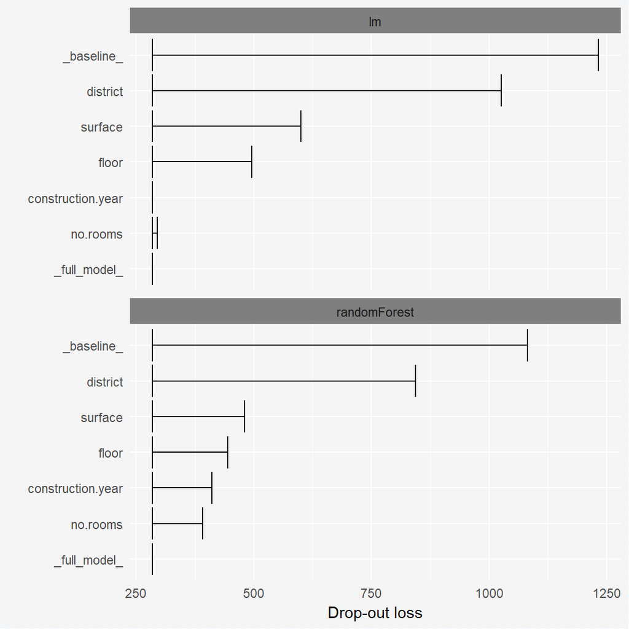

```r
plot(vi_lm, vi_rf)
```

Load plot: [`archivist::aread('pbiecek/DALEX_arepo/fbde7b0ab4644d76ef6817e38daf8424')`](https://raw.githubusercontent.com/pbiecek/DALEX_arepo/master/gallery/fbde7b0ab4644d76ef6817e38daf8424.rda)

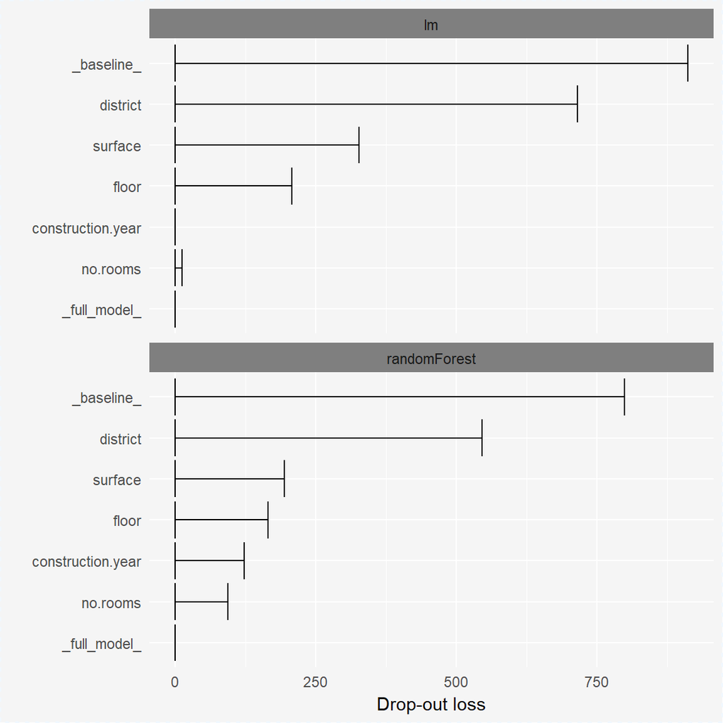

```r
vi_lm <- variable_importance(explainer_lm, loss_function = loss_root_mean_square, type = "difference")
vi_rf <- variable_importance(explainer_rf, loss_function = loss_root_mean_square, type = "difference")
plot(vi_lm, vi_rf)
```

Load vi_lm: [`archivist::aread('pbiecek/DALEX_arepo/a4b81b65fd697a7ca125c4e1d442b091')`](https://raw.githubusercontent.com/pbiecek/DALEX_arepo/master/gallery/a4b81b65fd697a7ca125c4e1d442b091.rda)

Load vi_rf: [`archivist::aread('pbiecek/DALEX_arepo/9378c068c88f52d6d32186d621ae1111')`](https://raw.githubusercontent.com/pbiecek/DALEX_arepo/master/gallery/9378c068c88f52d6d32186d621ae1111.rda)

Load plot: [`archivist::aread('pbiecek/DALEX_arepo/6fa63c1a5898402bf3a40e071398ce5f')`](https://raw.githubusercontent.com/pbiecek/DALEX_arepo/master/gallery/6fa63c1a5898402bf3a40e071398ce5f.rda)

### 3.2.2 Model specific

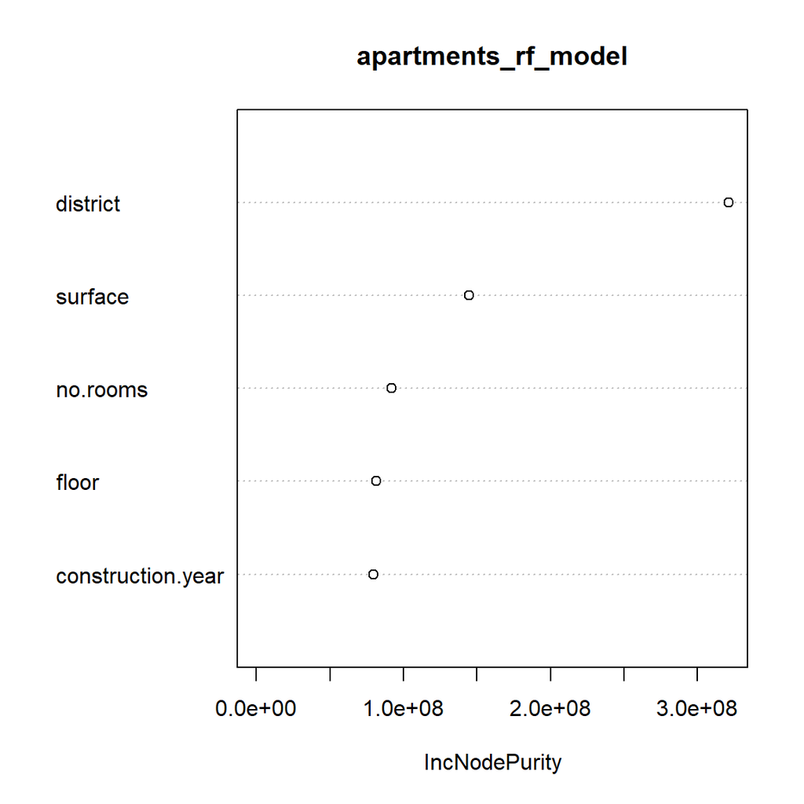

```r
varImpPlot(apartments_rf_model)
```

Load plot: [`archivist::aread('pbiecek/DALEX_arepo/f790743ed3b0df7001907202a07b3783')`](https://raw.githubusercontent.com/pbiecek/DALEX_arepo/master/gallery/f790743ed3b0df7001907202a07b3783.rda)

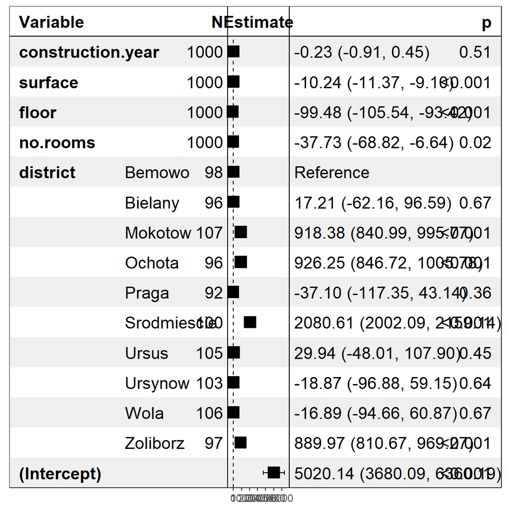

```r
library("forestmodel")
forest_model(apartments_lm_model)
```

Load plot: [`archivist::aread('pbiecek/DALEX_arepo/c49f8dd70699725006e4f66666f64279')`](https://raw.githubusercontent.com/pbiecek/DALEX_arepo/master/gallery/c49f8dd70699725006e4f66666f64279.rda)

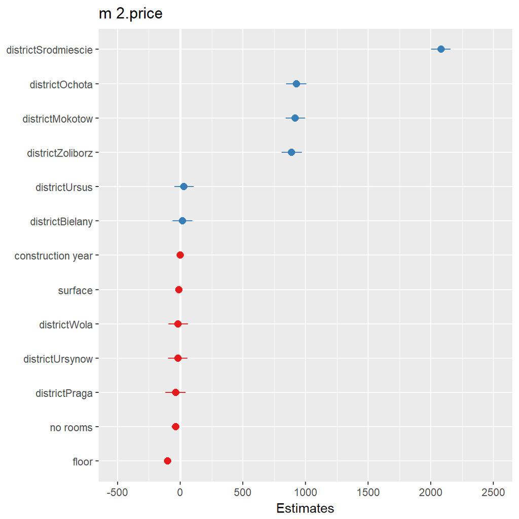

```r
library("sjPlot")
plot_model(apartments_lm_model, type = "est", sort.est = TRUE)
```

Load plot: [`archivist::aread('pbiecek/DALEX_arepo/50e3f9ae4aeeb8367650e2d36dbf8bce')`](https://raw.githubusercontent.com/pbiecek/DALEX_arepo/master/gallery/50e3f9ae4aeeb8367650e2d36dbf8bce.rda)

## 3.3 Variable response

### 3.3.1 Partial Dependence Plot

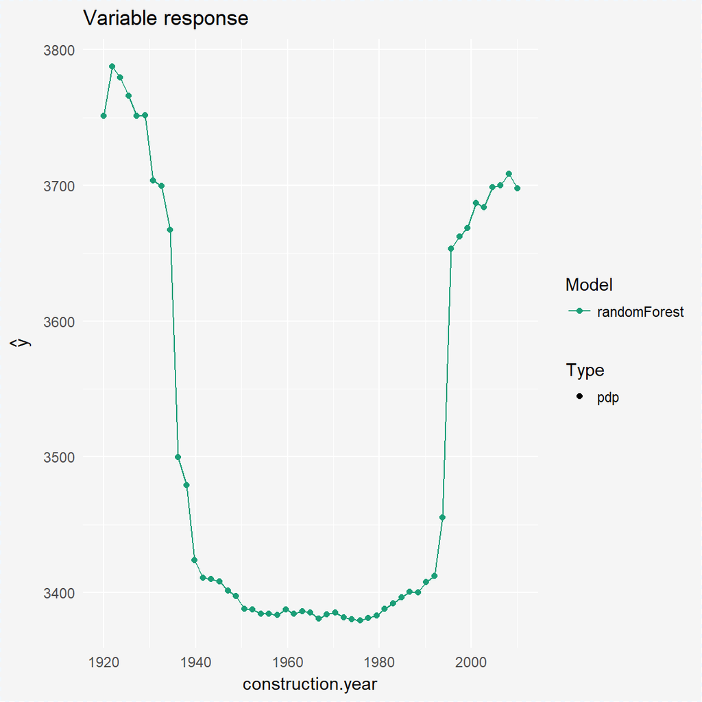

```r
sv_rf  <- single_variable(explainer_rf, variable =  "construction.year", type = "pdp")
plot(sv_rf)
```

Load sv_rf: [`archivist::aread('pbiecek/DALEX_arepo/3b15091e188843136583733465c765f2')`](https://raw.githubusercontent.com/pbiecek/DALEX_arepo/master/gallery/3b15091e188843136583733465c765f2.rda)

Load plot: [`archivist::aread('pbiecek/DALEX_arepo/a933d79008e54a2fbf5f80d00d399f90')`](https://raw.githubusercontent.com/pbiecek/DALEX_arepo/master/gallery/a933d79008e54a2fbf5f80d00d399f90.rda)

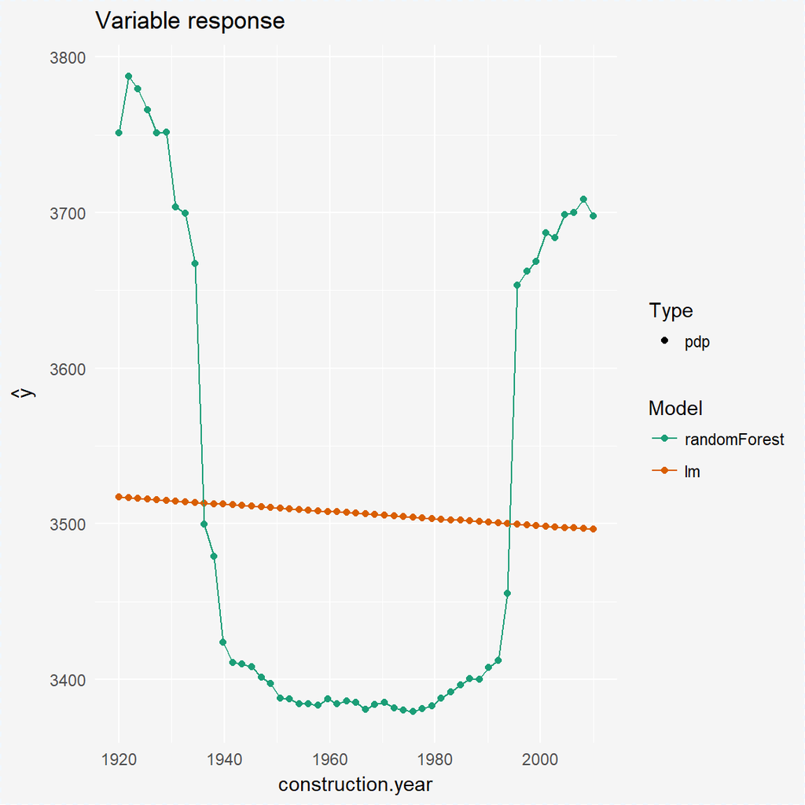

```r
sv_lm  <- single_variable(explainer_lm, variable =  "construction.year", type = "pdp")
plot(sv_rf, sv_lm)
```

Load sv_lm: [`archivist::aread('pbiecek/DALEX_arepo/19cfefe49ed77ff85c0dacbdf74a0177')`](https://raw.githubusercontent.com/pbiecek/DALEX_arepo/master/gallery/19cfefe49ed77ff85c0dacbdf74a0177.rda)

Load plot: [`archivist::aread('pbiecek/DALEX_arepo/8d66b624abe6163f4c2db1546d4c5e60')`](https://raw.githubusercontent.com/pbiecek/DALEX_arepo/master/gallery/8d66b624abe6163f4c2db1546d4c5e60.rda)

### 3.3.2 Accumulated Local Effects Plot

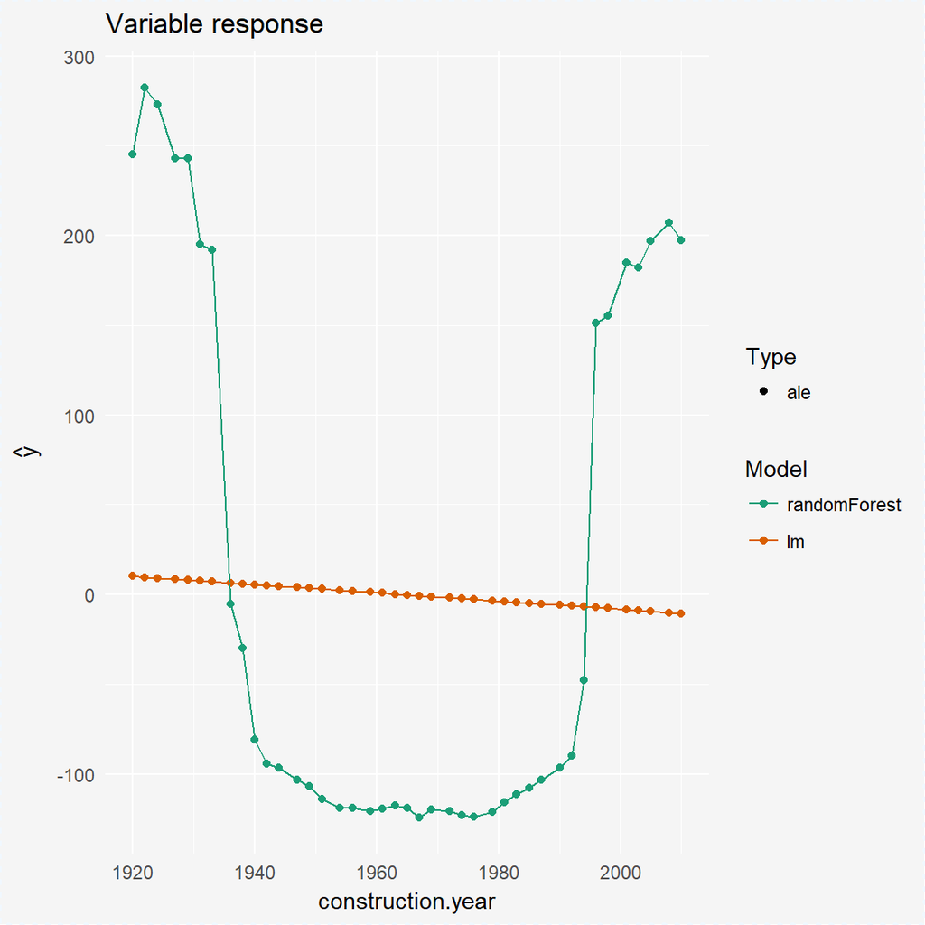

```r
sva_rf  <- single_variable(explainer_rf, variable = "construction.year", type = "ale")
sva_lm  <- single_variable(explainer_lm, variable = "construction.year", type = "ale")

plot(sva_rf, sva_lm)
```

Load sva_rf: [`archivist::aread('pbiecek/DALEX_arepo/9c620dfe7e63ccc8deae80bd6deaa99f')`](https://raw.githubusercontent.com/pbiecek/DALEX_arepo/master/gallery/9c620dfe7e63ccc8deae80bd6deaa99f.rda)

Load sva_lm: [`archivist::aread('pbiecek/DALEX_arepo/2b2da6d1d610fbacc8b16642a795687b')`](https://raw.githubusercontent.com/pbiecek/DALEX_arepo/master/gallery/2b2da6d1d610fbacc8b16642a795687b.rda)

Load plot: [`archivist::aread('pbiecek/DALEX_arepo/dc40f4d97311d12120e13a4790886a4d')`](https://raw.githubusercontent.com/pbiecek/DALEX_arepo/master/gallery/dc40f4d97311d12120e13a4790886a4d.rda)

### 3.3.3 Mering Path Plot

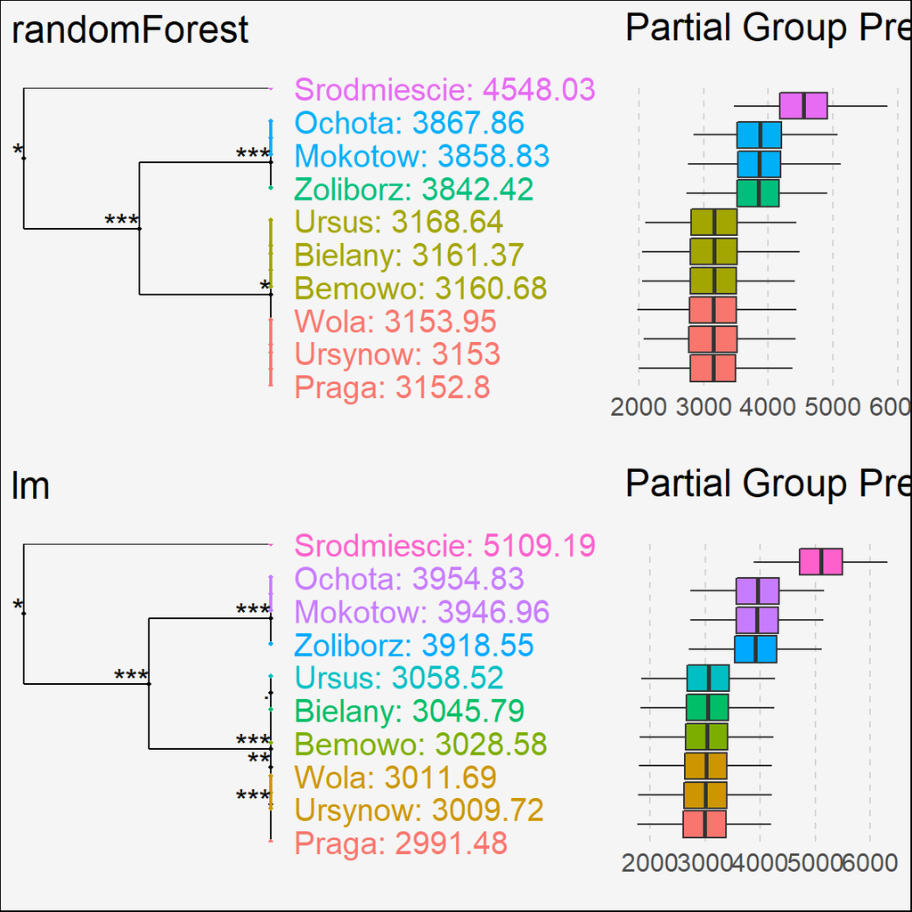

```r
svd_rf  <- single_variable(explainer_rf, variable = "district", type = "factor")
svd_lm  <- single_variable(explainer_lm, variable = "district", type = "factor")

plot(svd_rf, svd_lm)
```

Load svd_rf: [`archivist::aread('pbiecek/DALEX_arepo/37357f3521e9d1c08cc2870542969f49')`](https://raw.githubusercontent.com/pbiecek/DALEX_arepo/master/gallery/37357f3521e9d1c08cc2870542969f49.rda)

Load svd_lm: [`archivist::aread('pbiecek/DALEX_arepo/6cbf4993a3633e2230acaaa4c6f18eb2')`](https://raw.githubusercontent.com/pbiecek/DALEX_arepo/master/gallery/6cbf4993a3633e2230acaaa4c6f18eb2.rda)

Load plot: [`archivist::aread('pbiecek/DALEX_arepo/3d4b2cf15485dffd85f0ef18f8aa3724')`](https://raw.githubusercontent.com/pbiecek/DALEX_arepo/master/gallery/3d4b2cf15485dffd85f0ef18f8aa3724.rda)

# Chapter 4 Prediction understanding

```r
library("DALEX")
apartments_lm_model <- lm(m2.price ~ construction.year + surface + floor +
                      no.rooms + district, data = apartments)
library("randomForest")
set.seed(59)
apartments_rf_model <- randomForest(m2.price ~ construction.year + surface + floor +
                      no.rooms + district, data = apartments)
```

Load apartments_lm_model: [`archivist::aread('pbiecek/DALEX_arepo/3cafc60134a96b55cfc6071331e0b4e8')`](https://raw.githubusercontent.com/pbiecek/DALEX_arepo/master/gallery/3cafc60134a96b55cfc6071331e0b4e8.rda)

Load apartments_rf_model: [`archivist::aread('pbiecek/DALEX_arepo/dd78d435bf6e7c94d2286b5ca6be4909')`](https://raw.githubusercontent.com/pbiecek/DALEX_arepo/master/gallery/dd78d435bf6e7c94d2286b5ca6be4909.rda)

```r
explainer_lm <- explain(apartments_lm_model,
                       data = apartmentsTest[,2:6], y = apartmentsTest$m2.price)
explainer_rf <- explain(apartments_rf_model,
                       data = apartmentsTest[,2:6], y = apartmentsTest$m2.price)
```

Load explainer_lm: [`archivist::aread('pbiecek/DALEX_arepo/9cca29103ef24810307f2bd4c7919198')`](https://raw.githubusercontent.com/pbiecek/DALEX_arepo/master/gallery/9cca29103ef24810307f2bd4c7919198.rda)

Load explainer_rf: [`archivist::aread('pbiecek/DALEX_arepo/c8989ccd4160e539739b2f1204556451')`](https://raw.githubusercontent.com/pbiecek/DALEX_arepo/master/gallery/c8989ccd4160e539739b2f1204556451.rda)

## 4.1 Outlier detection

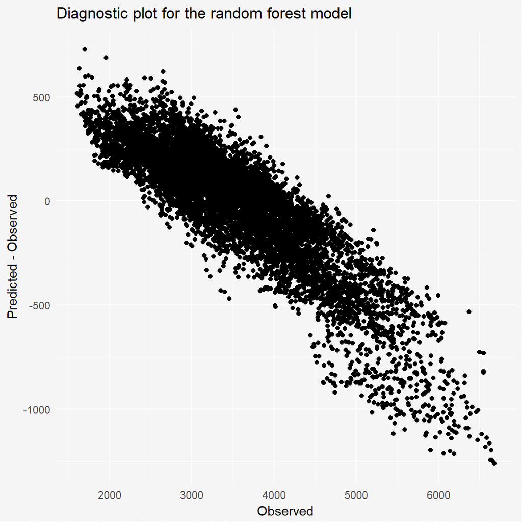

```r
mp_rf <- model_performance(explainer_rf)

library("ggplot2")
ggplot(mp_rf, aes(observed, diff)) + geom_point() +
        xlab("Observed") + ylab("Predicted - Observed") +
        ggtitle("Diagnostic plot for the random forest model") + theme_mi2()
```

Load mp_rf: [`archivist::aread('pbiecek/DALEX_arepo/b4eb12644fbb0caad889c7f830a8a364')`](https://raw.githubusercontent.com/pbiecek/DALEX_arepo/master/gallery/b4eb12644fbb0caad889c7f830a8a364.rda)

Load plot: [`archivist::aread('pbiecek/DALEX_arepo/5807e4adea562678cff2abf32882ec9e')`](https://raw.githubusercontent.com/pbiecek/DALEX_arepo/master/gallery/5807e4adea562678cff2abf32882ec9e.rda)

```r
which.min(mp_rf$diff)
```

```
[1] 161
```

```r
## 1161
new_apartment <- apartmentsTest[which.min(mp_rf$diff), ]
new_apartment
```

```
     m2.price construction.year surface floor no.rooms    district
1161     6679              2005      22     1        2 Srodmiescie
```

Load new_apartment: [`archivist::aread('pbiecek/DALEX_arepo/4c3b17f8fab70c180a77c492535372b5')`](https://raw.githubusercontent.com/pbiecek/DALEX_arepo/master/gallery/4c3b17f8fab70c180a77c492535372b5.rda)

4.2 Prediction breakDown

```r
new_apartment_rf <- single_prediction(explainer_rf, observation = new_apartment)
breakDown:::print.broken(new_apartment_rf)
```

```
                           contribution
(Intercept)                       0.000
+ district = Srodmiescie       1042.059
+ surface = 22                  364.385
+ floor = 1                     279.526
+ no.rooms = 2                  279.070
+ construction.year = 2005      -54.566
final_prognosis                1910.474
baseline:  3505.971
```

Load new_apartment_rf: [`archivist::aread('pbiecek/DALEX_arepo/72b47850aea11264f1c7d409aa0baf22')`](https://raw.githubusercontent.com/pbiecek/DALEX_arepo/master/gallery/72b47850aea11264f1c7d409aa0baf22.rda)

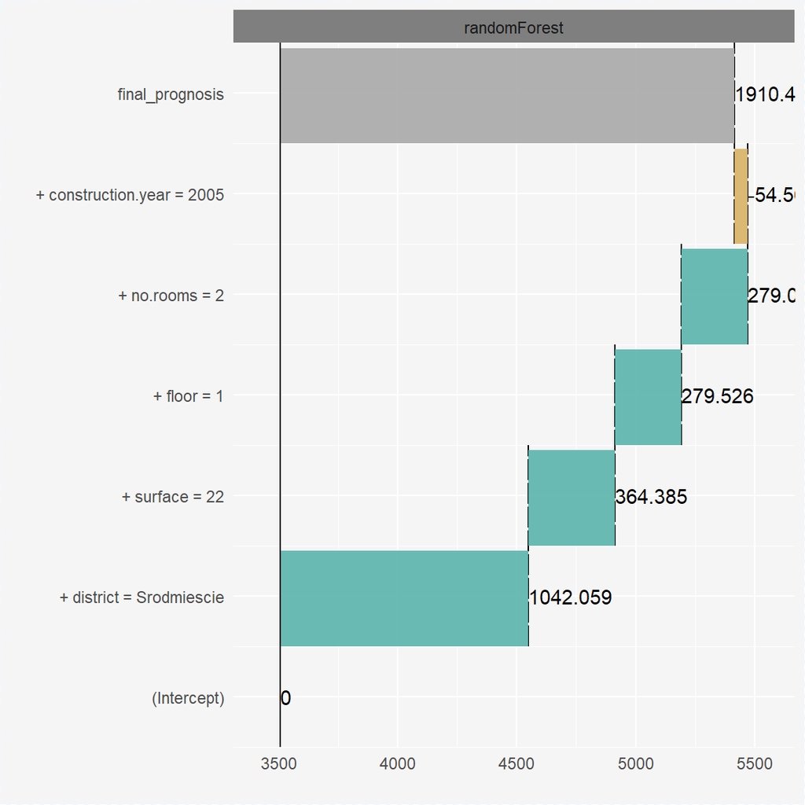

```r
plot(new_apartment_rf)
```

Load plot: [`archivist::aread('pbiecek/DALEX_arepo/b29581c5d04f02da5131322223b47382')`](https://raw.githubusercontent.com/pbiecek/DALEX_arepo/master/gallery/b29581c5d04f02da5131322223b47382.rda)

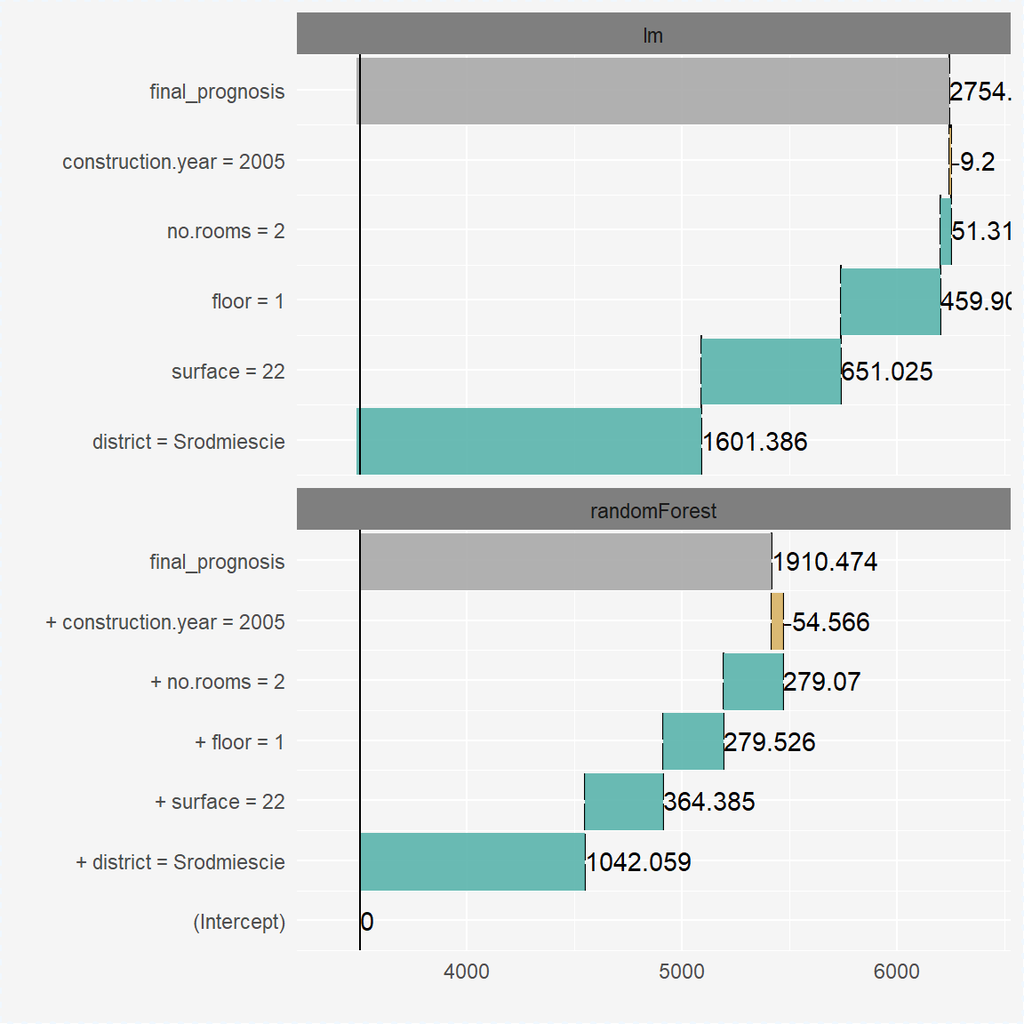

```r
new_apartment_lm <- single_prediction(explainer_lm, observation = new_apartment)
plot(new_apartment_lm, new_apartment_rf)
```

Load new_apartment_lm: [`archivist::aread('pbiecek/DALEX_arepo/dabe9bdc70e192bde65d13c657d7792e')`](https://raw.githubusercontent.com/pbiecek/DALEX_arepo/master/gallery/dabe9bdc70e192bde65d13c657d7792e.rda)

Load plot: [`archivist::aread('pbiecek/DALEX_arepo/f07b6404519ede9824f3b990d4b76a46')`](https://raw.githubusercontent.com/pbiecek/DALEX_arepo/master/gallery/f07b6404519ede9824f3b990d4b76a46.rda)

# Chapter 5 Epilogue

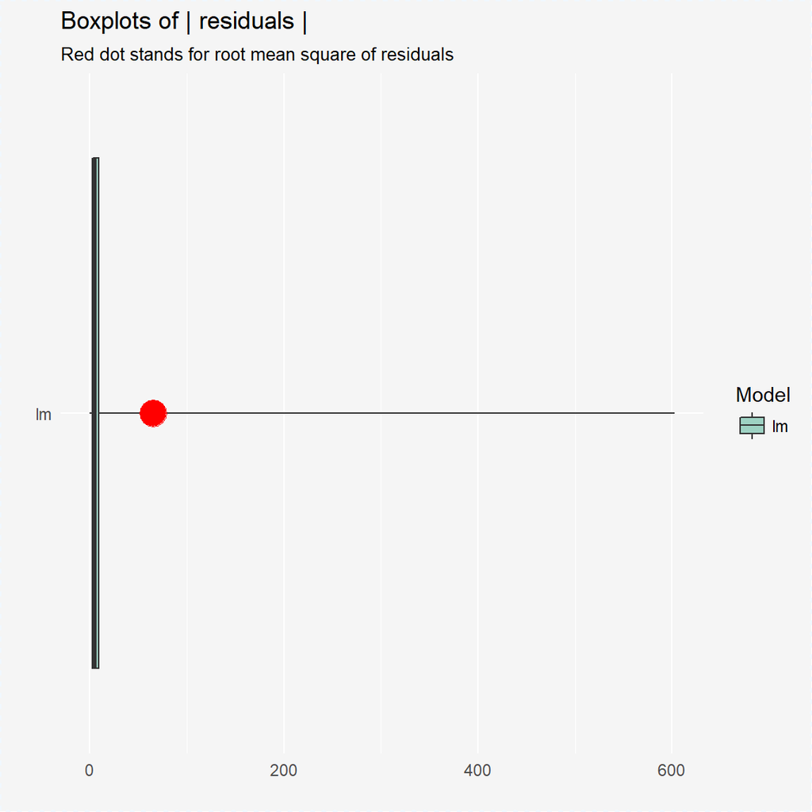

```r
library("DALEX")

apartments_lm_model_improved <- lm(m2.price ~ I(construction.year < 1935 | construction.year > 1995) + surface + floor +
                         no.rooms + district, data = apartments)

explainer_lm_improved <- explain(apartments_lm_model_improved,
                          data = apartmentsTest[,2:6], y = apartmentsTest$m2.price)

mp_lm_improved <- model_performance(explainer_lm_improved)
plot(mp_lm_improved, geom = "boxplot")
```

Load apartments_lm_model_improved: [`archivist::aread('pbiecek/DALEX_arepo/875e24ef2046c332d09d29fdd5121b68')`](https://raw.githubusercontent.com/pbiecek/DALEX_arepo/master/gallery/875e24ef2046c332d09d29fdd5121b68.rda)

Load explainer_lm_improved: [`archivist::aread('pbiecek/DALEX_arepo/3340da4ac4089ac71a5b709152c2cf1f')`](https://raw.githubusercontent.com/pbiecek/DALEX_arepo/master/gallery/3340da4ac4089ac71a5b709152c2cf1f.rda)

Load mp_lm_improved: [`archivist::aread('pbiecek/DALEX_arepo/3ab0d8ddb6858b8f265dea16196b4574')`](https://raw.githubusercontent.com/pbiecek/DALEX_arepo/master/gallery/3ab0d8ddb6858b8f265dea16196b4574.rda)

Load plot: [`archivist::aread('pbiecek/DALEX_arepo/d02676ebb7f0d97c1eb9e34046a9c4fc')`](https://raw.githubusercontent.com/pbiecek/DALEX_arepo/master/gallery/d02676ebb7f0d97c1eb9e34046a9c4fc.rda)

# Chapter 6 Exercises

```r
library("DALEX")
library("gbm")

apartments_gbm_model <- gbm(m2.price ~ construction.year + surface + floor +
                         no.rooms + district, data = apartments, n.trees = 1000)

explainer_gbm <- explain(apartments_gbm_model,
                          data = apartmentsTest[,2:6], y = apartmentsTest$m2.price,
                         predict_function = function(m, d) predict(m, d, n.trees = 1000))
```

Load apartments_gbm_model: [`archivist::aread('pbiecek/DALEX_arepo/82652291df175e0dabb45a229a951160')`](https://raw.githubusercontent.com/pbiecek/DALEX_arepo/master/gallery/82652291df175e0dabb45a229a951160.rda)

Load explainer_gbm: [`archivist::aread('pbiecek/DALEX_arepo/b7e15ba5c1e190042f711d3a8f374b5f')`](https://raw.githubusercontent.com/pbiecek/DALEX_arepo/master/gallery/b7e15ba5c1e190042f711d3a8f374b5f.rda)

```r
library("nnet")
apartments_nnet_model <- nnet(m2.price ~ construction.year + surface + floor +
                         no.rooms + district, data = apartments,
                         linout=TRUE,
                         size = 50, maxit=100)

explainer_nnet <- explain(apartments_nnet_model,
                          data = apartmentsTest[,2:6], y = apartmentsTest$m2.price)
```

Load apartments_nnet_model: [`archivist::aread('pbiecek/DALEX_arepo/9c86f52b8ae7215500a1b575d52c21c0')`](https://raw.githubusercontent.com/pbiecek/DALEX_arepo/master/gallery/9c86f52b8ae7215500a1b575d52c21c0.rda)

Load explainer_nnet: [`archivist::aread('pbiecek/DALEX_arepo/4d3fccd19e07a45d4d449a5e143a3611')`](https://raw.githubusercontent.com/pbiecek/DALEX_arepo/master/gallery/4d3fccd19e07a45d4d449a5e143a3611.rda)

```r
library("e1071")
apartments_svm_model <- svm(m2.price ~ construction.year + surface + floor +
                         no.rooms + district, data = apartments)

explainer_svm <- explain(apartments_svm_model,
                          data = apartmentsTest[,2:6], y = apartmentsTest$m2.price)
```

Load apartments_svm_model: [`archivist::aread('pbiecek/DALEX_arepo/f2671a05682c892a1fc549fdb71bb762')`](https://raw.githubusercontent.com/pbiecek/DALEX_arepo/master/gallery/f2671a05682c892a1fc549fdb71bb762.rda)

Load explainer_svm: [`archivist::aread('pbiecek/DALEX_arepo/34a5ced4367327f6c2d0e0fbd61a504b')`](https://raw.githubusercontent.com/pbiecek/DALEX_arepo/master/gallery/34a5ced4367327f6c2d0e0fbd61a504b.rda)

```r
library("caret")
mapartments <- model.matrix(m2.price ~ ., data = apartments)
mapartmentsTest <- model.matrix(m2.price ~ ., data = apartmentsTest)
apartments_knn_model <- knnreg(mapartments, apartments[,1], k = 5)

explainer_knn <- explain(apartments_knn_model,
                          data = mapartmentsTest, y = apartmentsTest$m2.price)
```

Load apartments_knn_model: [`archivist::aread('pbiecek/DALEX_arepo/72e749ce39603be905929dd3d33f1044')`](https://raw.githubusercontent.com/pbiecek/DALEX_arepo/master/gallery/72e749ce39603be905929dd3d33f1044.rda)

Load explainer_knn: [`archivist::aread('pbiecek/DALEX_arepo/ab23b6179d67c0eec98a3d2c0693f575')`](https://raw.githubusercontent.com/pbiecek/DALEX_arepo/master/gallery/ab23b6179d67c0eec98a3d2c0693f575.rda)

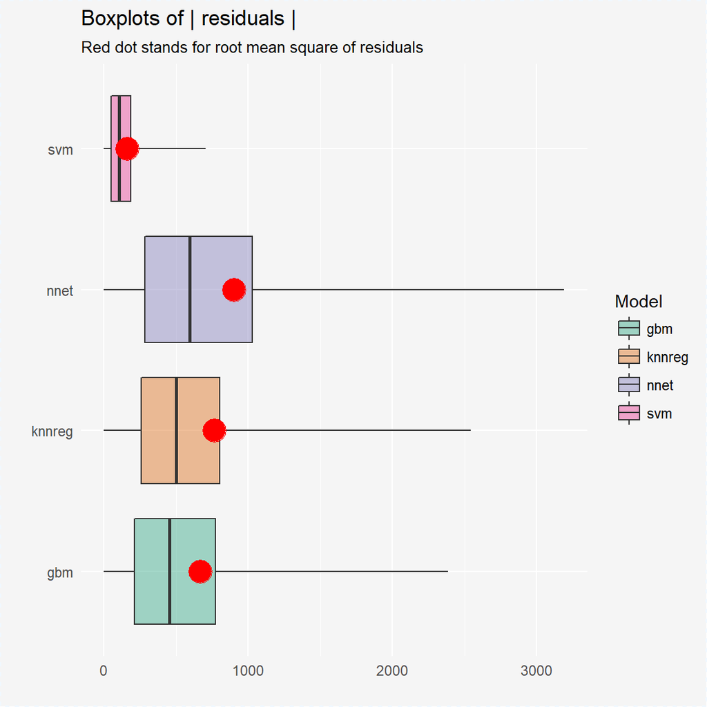

```r
mp_knn <- model_performance(explainer_knn)
mp_svm <- model_performance(explainer_svm)
mp_gbm <- model_performance(explainer_gbm)
mp_nnet <- model_performance(explainer_nnet)
plot(mp_gbm, mp_nnet, mp_svm, mp_knn, geom = "boxplot")
```

Load mp_knn: [`archivist::aread('pbiecek/DALEX_arepo/d8e57d1f8f381af888dda24125d8db28')`](https://raw.githubusercontent.com/pbiecek/DALEX_arepo/master/gallery/d8e57d1f8f381af888dda24125d8db28.rda)

Load mp_svm: [`archivist::aread('pbiecek/DALEX_arepo/704eb15fc5c6177c3f40b89a0de5e3a9')`](https://raw.githubusercontent.com/pbiecek/DALEX_arepo/master/gallery/704eb15fc5c6177c3f40b89a0de5e3a9.rda)

Load mp_gbm: [`archivist::aread('pbiecek/DALEX_arepo/6e46302c1f306439c45e366444bc4e20')`](https://raw.githubusercontent.com/pbiecek/DALEX_arepo/master/gallery/6e46302c1f306439c45e366444bc4e20.rda)

Load mp_nnet: [`archivist::aread('pbiecek/DALEX_arepo/337bc4adc3a897af55269aba0d52eb80')`](https://raw.githubusercontent.com/pbiecek/DALEX_arepo/master/gallery/337bc4adc3a897af55269aba0d52eb80.rda)

Load plot: [`archivist::aread('pbiecek/DALEX_arepo/8cf1b957b0c9ca8b9d3da46af763c41e')`](https://raw.githubusercontent.com/pbiecek/DALEX_arepo/master/gallery/8cf1b957b0c9ca8b9d3da46af763c41e.rda)